# Mini-project 2 Template

Author

Alexandre Turgis, Kunal Ghosh

Feel free to change render format to html using

format: html

self-contained: true

## Instructions

This is the template document for mini-project 2. You must use the template document for your code, since it will make it much easier to follow.

## Libraries and data load

Put whatever libraries you use here.

```r
library(dplyr)
library(knitr)
library(ggplot2)
library(forcats)
library(tidyr)
library(tidyverse)
```

Load your data here

```r
# project2_merged.csv = Mini-Project 1 data merged with democracy2020.csv (by geo)
project2_merged <- read_csv("project2_merged.csv", show_col_types = FALSE) |>
  select(-1) |>
  mutate(Democracy = factor(Democracy, levels = c("No", "Yes")))
```

## Exploratory data analysis

For this section graph and find statistics for each of your predictor variables vs the response. You do not need to look at the predictor variables individually

## Variable 1: Sanitation Access

### Graph and description

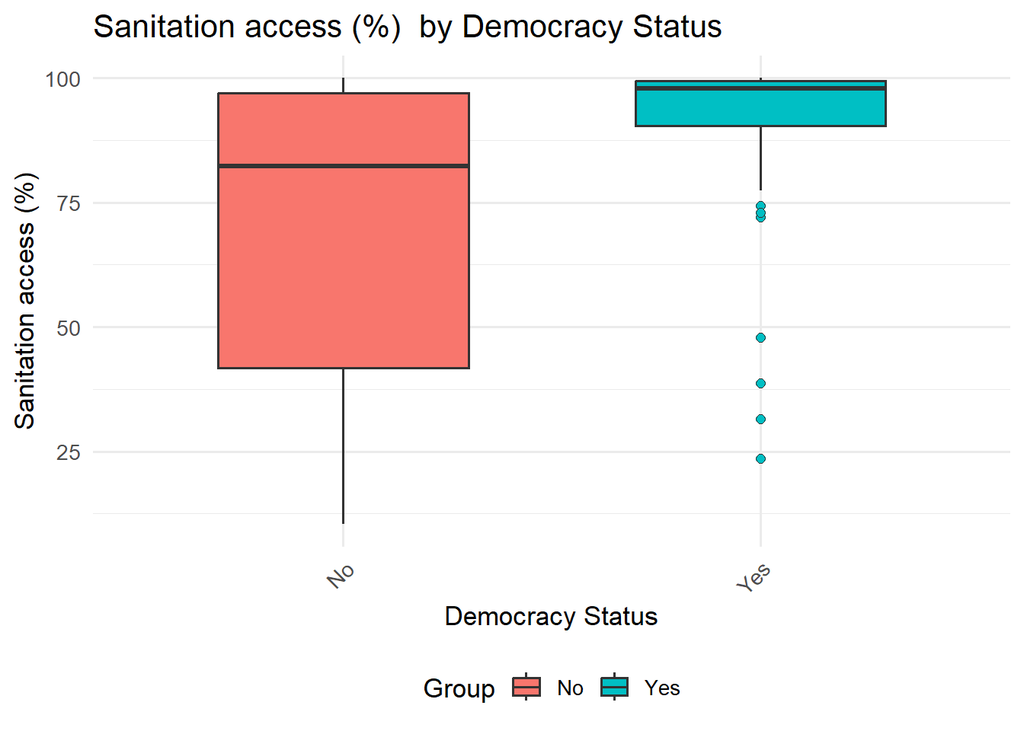

```
# A tibble: 1 × 6
      n  mean median    sd   min   max
  <int> <dbl>  <dbl> <dbl> <dbl> <dbl>
1   154  79.4   92.5  26.6  10.4   100
```

```
# A tibble: 6 × 3
  name                     Democracy sanitation_access_pct
  <chr>                    <fct>                     <dbl>
1 Ethiopia                 No                         10.4
2 Niger                    No                         16.3
3 Congo, Dem. Rep.         No                         16.3
4 Chad                     No                         13.1
5 Central African Republic No                         14.0
6 Madagascar               No                         15.4
```

```r
p1; t1; o1
```

## Variable 2: Food Supply

### Graph and description

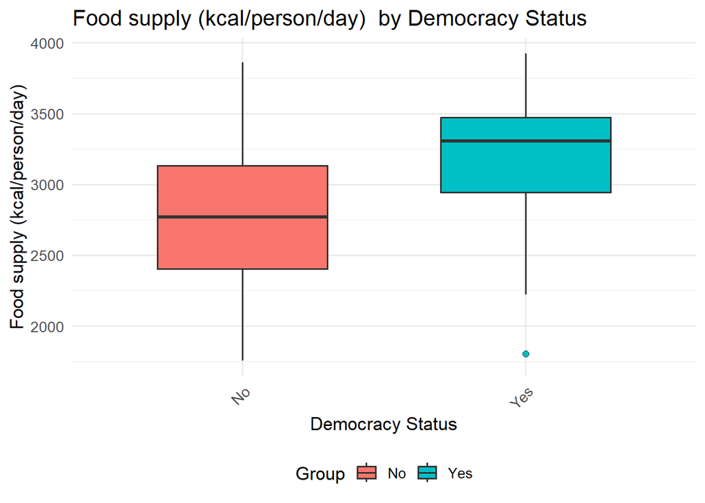

```
# A tibble: 1 × 6
      n  mean median    sd   min   max
  <int> <dbl>  <dbl> <dbl> <dbl> <dbl>
1   160 2964.  2992.  494. 1755. 3923.
```

```
# A tibble: 0 × 3
# ℹ 3 variables: name <chr>, Democracy <fct>,
#   food_supply_kcal_per_person_day <dbl>
```

```r
p2; t2; o2
```

### Stats and description

looking at the means of food supply by democracy status, non-democracies fall below the total mean (~2963 kcal/person/day) while Democracies fall above the total mean. Implied in this analysis is that the samples by democracy status are significantly different and would be a good candidate for a single variable model. There are no significant outliers in this comparison.

## Variable 3: Deaths from Murder

### Graph and description

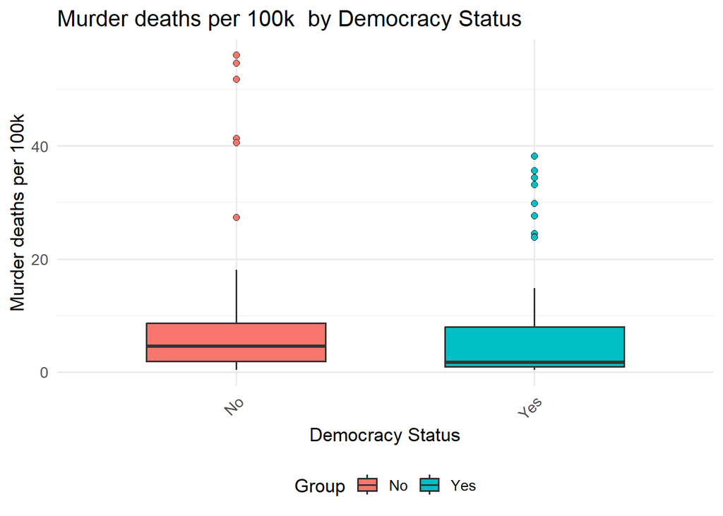

```
# A tibble: 1 × 6
      n  mean median    sd   min   max
  <int> <dbl>  <dbl> <dbl> <dbl> <dbl>
1   165  7.38   3.01  10.5 0.322  56.1
```

```
# A tibble: 5 × 3
  name                Democracy murder_deaths_per_100k
  <chr>               <fct>                      <dbl>
1 Haiti               No                          56.1
2 El Salvador         No                          54.7
3 Eritrea             No                          51.8
4 Trinidad and Tobago Yes                         23.9
5 Ecuador             Yes                         24.0
```

```r
p3; t3; o3
```

## Variable 4: Child Deaths

### Graph and description

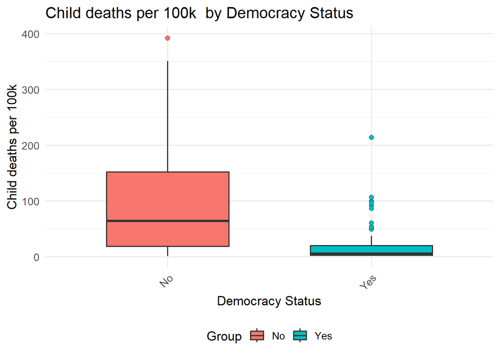

```
# A tibble: 1 × 6
      n  mean median    sd   min   max
  <int> <dbl>  <dbl> <dbl> <dbl> <dbl>
1   165  63.9   23.0  84.5  1.46  392.
```

```
# A tibble: 5 × 3
  name                     Democracy child_deaths_per_100k
  <chr>                    <fct>                     <dbl>
1 Central African Republic No                         392.
2 Nigeria                  No                         351.
3 Chad                     No                         350.
4 Burkina Faso             No                         248.
5 Benin                    No                         255.
```

```r
p4; t4; o4
```

### Stats and description

looking at the means of child deaths per capita by democracy status, democracies fell below the total mean (~64 per capita) non-democracies had higher child deaths per capita. The two measn seem to be significantly different, and this variable is a good candidate for the single vairable model. All five farthest outliers are non-democracies and have above 240 child deaths per capita.

## Variable 5: Female Head of State

### Graph and description

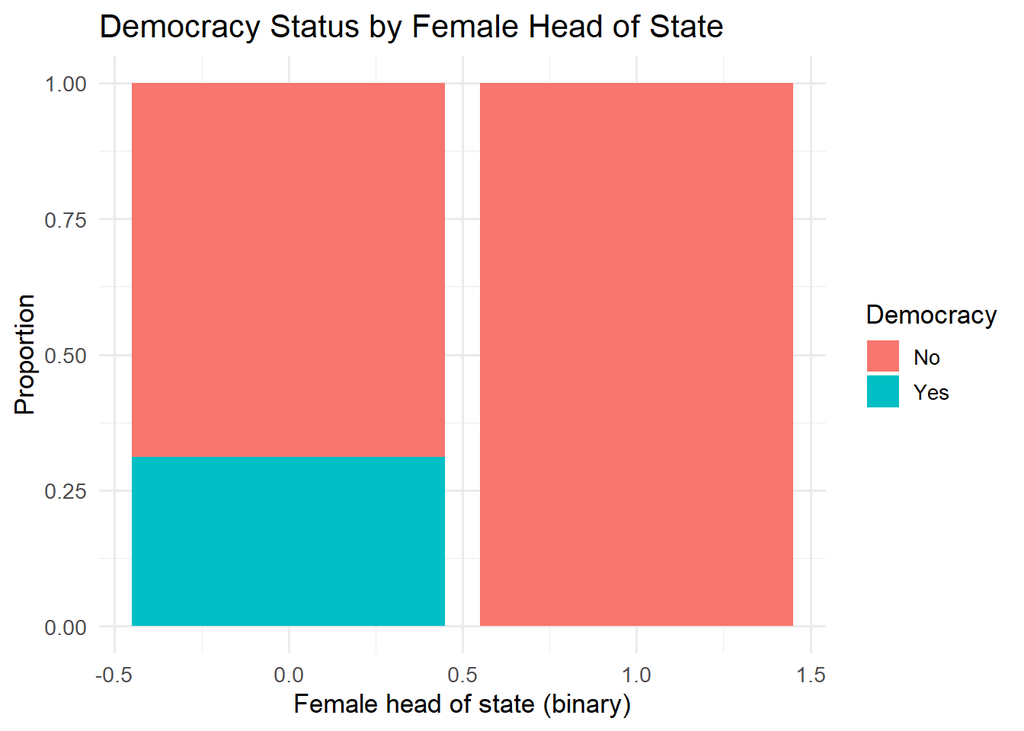

```r
ggplot(project2_merged, aes(x = female_hos_binary, fill = Democracy)) + geom_bar(position = "fill") + labs( title = "Democracy Status by Female Head of State", x = "Female head of state (binary)", y = "Proportion", fill = "Democracy" ) + theme_minimal(base_size = 13)
```

```r
#two way table
as.data.frame(table(project2_merged$female_hos_binary, project2_merged$Democracy))
```

```
  Var1 Var2 Freq
1    0   No   62
2    1   No    1
3    0  Yes   28
4    1  Yes    0
```

```r
#row proportions
as.data.frame(prop.table(table(project2_merged$female_hos_binary, project2_merged$Democracy), margin = 2))
```

```
  Var1 Var2       Freq
1    0   No 0.98412698
2    1   No 0.01587302
3    0  Yes 1.00000000
4    1  Yes 0.00000000
```

```r
#column proportions
as.data.frame(prop.table(table(project2_merged$female_hos_binary, project2_merged$Democracy)))
```

```
  Var1 Var2       Freq
1    0   No 0.68131868
2    1   No 0.01098901
3    0  Yes 0.30769231
4    1  Yes 0.00000000
```

### Stats and description

The only state that survived into this merged dataset is Tanzania, being a one party state and a non-democracy. I am beginning to think the Female head of state category was poorly designed, maybe if the variable was redifined to mean “has had a female head of state” versus “has a female head of state”. This variable does not have enough data for both democracies and non-democracies to be considered for the single variable model.

## Which variable for single variable models?

We are going with **food supply** for our single variable model because it showed one of the clearest differences between the two groups (democracies have a higher food supply) and, unlike sanitation access, it has only 5 missing values and is not squeezed against a ceiling of 100%. Child deaths and sanitation access also separate the groups well, but food supply is the variable we chose in the exploratory analysis.

## kNN classification

Setup shared by both kNN models: rows with missing values in the variables used are dropped, predictors are standardized (kNN is distance based, so kcal and percent would otherwise be on very different scales), and the same 10 cross-validation folds are used for every candidate k so the comparisons are fair. Standardization is done inside each fold using only the training part of the fold. “Yes” (democracy) is treated as the positive class.

```r
set.seed(380)

# standardize test data with training means / sds
scale_by <- function(train, test) {
  m <- colMeans(train); s <- apply(train, 2, sd)
  list(train = scale(train, m, s), test = scale(test, m, s))
}

# 10-fold CV accuracy of kNN for a given k
cv_knn <- function(dat, vars, k, folds) {
  X <- as.matrix(dat[, vars]); y <- dat$Democracy
  acc <- sapply(sort(unique(folds)), function(f) {
    tr <- folds != f
    sc <- scale_by(X[tr, , drop = FALSE], X[!tr, , drop = FALSE])
    pred <- class::knn(sc$train, sc$test, y[tr], k = k)
    mean(pred == y[!tr])
  })
  mean(acc)
}

# training (resubstitution) accuracy
train_knn <- function(dat, vars, k) {
  X <- scale(as.matrix(dat[, vars]))
  mean(class::knn(X, X, dat$Democracy, k = k) == dat$Democracy)
}

tune_knn <- function(dat, vars, ks = 1:30) {
  folds <- sample(rep(1:10, length.out = nrow(dat)))
  tibble(k = ks,
         cv_accuracy = sapply(ks, function(k) cv_knn(dat, vars, k, folds)))
}

plot_tune <- function(tune, title) {
  best <- tune |> slice_max(cv_accuracy, n = 1, with_ties = FALSE)
  ggplot(tune, aes(k, cv_accuracy)) +
    geom_line() + geom_point() +
    geom_point(data = best, color = "red", size = 3) +
    labs(title = title, x = "k (number of neighbors)",
         y = "10-fold CV accuracy") +
    theme_minimal(base_size = 13)
}

# baseline: always guess the majority class
baseline <- max(prop.table(table(project2_merged$Democracy)))
```

### Single variable model

kNN using food supply (kcal per person per day) only.

```r
d_food <- project2_merged |>
  select(Democracy, food_supply_kcal_per_person_day) |>
  drop_na()
nrow(d_food)
```

```
[1] 160
```

#### Model tuning to find k

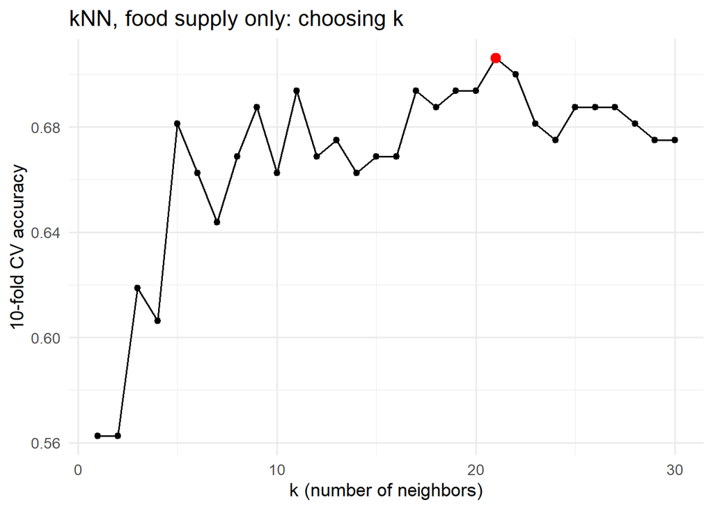

```r
tune_food <- tune_knn(d_food, "food_supply_kcal_per_person_day")
plot_tune(tune_food, "kNN, food supply only: choosing k")
```

```r
best_k_food <- tune_food |>
  slice_max(cv_accuracy, n = 1, with_ties = FALSE) |> pull(k)
tune_food |> slice_max(cv_accuracy, n = 5, with_ties = FALSE)
```

```
# A tibble: 5 × 2
      k cv_accuracy
  <int>       <dbl>
1    21       0.706
2    22       0.7
3    11       0.694
4    17       0.694
5    19       0.694
```

```r
best_k_food
```

```
[1] 21
```

#### Model for best k

```r
X <- scale(as.matrix(d_food[, "food_supply_kcal_per_person_day"]))
knn_food <- class::knn(X, X, d_food$Democracy, k = best_k_food)
table(Predicted = knn_food, Actual = d_food$Democracy)
```

```
         Actual
Predicted No Yes
      No  59  20
      Yes 28  53
```

#### Model evaluation-accuracy, cv for overfitting

```r
acc_knn_food_train <- train_knn(d_food, "food_supply_kcal_per_person_day", best_k_food)
acc_knn_food_cv    <- max(tune_food$cv_accuracy)
tibble(model = "kNN, food supply", k = best_k_food,
       training_accuracy = acc_knn_food_train,
       cv_accuracy = acc_knn_food_cv,
       gap = acc_knn_food_train - acc_knn_food_cv,
       baseline = baseline)
```

```
# A tibble: 1 × 6
  model                k training_accuracy cv_accuracy      gap baseline
  <chr>            <int>             <dbl>       <dbl>    <dbl>    <dbl>
1 kNN, food supply    21               0.7       0.706 -0.00625    0.552
```

Using food supply alone, the best k was 21 (10-fold CV accuracy about 0.71). That is only moderately better than always guessing “No” (about 55% of countries are non-democracies). Training accuracy (0.70) and CV accuracy (0.71) are essentially equal, so there is no sign of overfitting; the large k is a smooth, heavily averaged model. Note that the CV accuracy of the *best* k is slightly optimistic because we picked k by looking at the same folds. With only one predictor, there is a lot of overlap between the two groups, which caps the accuracy.

### All variable model

kNN using sanitation access, food supply, murder rate and child death rate (female head of state excluded, see above).

```r
all_vars <- c("sanitation_access_pct", "food_supply_kcal_per_person_day",
              "murder_deaths_per_100k", "child_deaths_per_100k")
d_all <- project2_merged |>
  select(Democracy, all_of(all_vars)) |>
  drop_na()
nrow(d_all)
```

```
[1] 152
```

#### Model tuning to find k using cv.

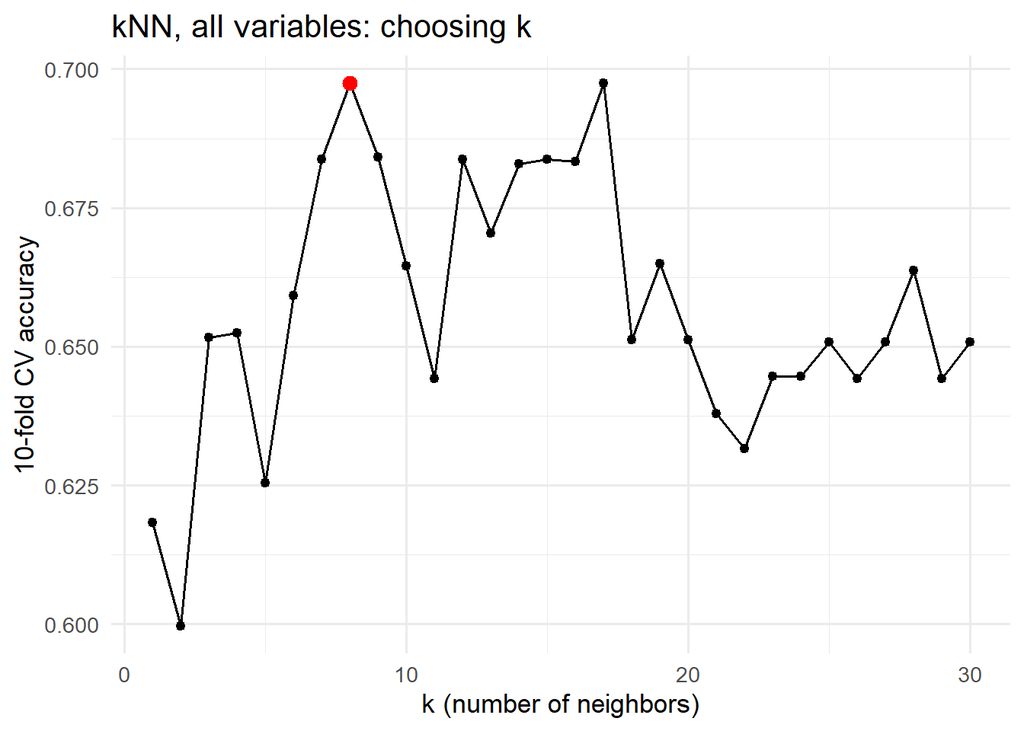

```r
tune_all <- tune_knn(d_all, all_vars)
plot_tune(tune_all, "kNN, all variables: choosing k")
```

```r
best_k_all <- tune_all |>
  slice_max(cv_accuracy, n = 1, with_ties = FALSE) |> pull(k)
tune_all |> slice_max(cv_accuracy, n = 5, with_ties = FALSE)
```

```
# A tibble: 5 × 2
      k cv_accuracy
  <int>       <dbl>
1     8       0.698
2    17       0.698
3     9       0.684
4     7       0.684
5    12       0.684
```

```r
best_k_all
```

```
[1] 8
```

#### Model for best k

```r
X <- scale(as.matrix(d_all[, all_vars]))
knn_all <- class::knn(X, X, d_all$Democracy, k = best_k_all)
table(Predicted = knn_all, Actual = d_all$Democracy)
```

```
         Actual
Predicted No Yes
      No  61  13
      Yes 20  58
```

#### Model evaluation-accuracy, cv for overfitting

```r
acc_knn_all_train <- train_knn(d_all, all_vars, best_k_all)
acc_knn_all_cv    <- max(tune_all$cv_accuracy)
tibble(model = "kNN, all variables", k = best_k_all,
       training_accuracy = acc_knn_all_train,
       cv_accuracy = acc_knn_all_cv,
       gap = acc_knn_all_train - acc_knn_all_cv,
       baseline = max(prop.table(table(d_all$Democracy))))
```

```
# A tibble: 1 × 6
  model                  k training_accuracy cv_accuracy    gap baseline
  <chr>              <int>             <dbl>       <dbl>  <dbl>    <dbl>
1 kNN, all variables     8             0.770       0.698 0.0722    0.533
```

With all four predictors the best k was 8 (CV accuracy about 0.70). The training accuracy (0.77) is clearly higher than the CV accuracy (0.70), a gap of about 7 points, so this model fits the training data better than it predicts new countries, which is a mild sign of overfitting. The CV curve is also noisy across k, so the exact choice of k is not very stable.

### Which model was best?

The two kNN models are essentially tied on cross-validated accuracy (0.71 for food supply only vs 0.70 for all variables), and with roughly 150 countries a difference of 1 point is well within noise (the standard error of an accuracy estimate is about 4 points). The multivariate model is more complex, needs more complete data (8 fewer countries) and shows a bigger training-vs-CV gap, while buying no extra accuracy. So the **single variable (food supply) kNN model is best**: the added complexity of the all-variable model was not worth it.

## Logistic Regression

Same data and the same “Yes” = positive class. Predicted probabilities above 0.5 are classified as democracies. Cross-validation uses 10 folds; ROC curves and AUC are computed from the out-of-fold predicted probabilities so that they are not overly optimistic.

```r
library(pROC)
set.seed(380)

cv_logit <- function(dat, formula) {
  folds <- sample(rep(1:10, length.out = nrow(dat)))
  p <- numeric(nrow(dat))
  for (f in 1:10) {
    fit <- glm(formula, data = dat[folds != f, ], family = binomial)
    p[folds == f] <- predict(fit, dat[folds == f, ], type = "response")
  }
  list(prob = p,
       accuracy = mean((p > 0.5) == (dat$Democracy == "Yes")),
       roc = roc(dat$Democracy, p, levels = c("No", "Yes"), direction = "<", quiet = TRUE))
}
```

### Single variable model

#### Model

```r
logit_food <- glm(Democracy ~ food_supply_kcal_per_person_day,
                  data = d_food, family = binomial)
summary(logit_food)
```

```
Call:
glm(formula = Democracy ~ food_supply_kcal_per_person_day, family = binomial,
    data = d_food)

Coefficients:
                                  Estimate Std. Error z value Pr(>|z|)
(Intercept)                     -6.7113177  1.2953640  -5.181 2.21e-07 ***
food_supply_kcal_per_person_day  0.0021835  0.0004244   5.145 2.68e-07 ***
---
Signif. codes:  0 '***' 0.001 '**' 0.01 '*' 0.05 '.' 0.1 ' ' 1

(Dispersion parameter for binomial family taken to be 1)

    Null deviance: 220.58  on 159  degrees of freedom
Residual deviance: 186.13  on 158  degrees of freedom
AIC: 190.13

Number of Fisher Scoring iterations: 3
```

#### Equation and Graph of model

```r
b <- coef(logit_food)
b
```

```
                    (Intercept) food_supply_kcal_per_person_day
                    -6.71131772                      0.00218351
```

```r
exp(b[2] * 100)   # odds multiplier for +100 kcal per person per day
```

```
food_supply_kcal_per_person_day
                       1.244024
```

```r
-b[1] / b[2]      # food supply at which P(democracy) = 0.5
```

```
(Intercept)
   3073.638
```

$$\log\left(\frac{\hat p}{1-\hat p}\right) = -6.7113 + 0.002184 \times \text{FoodSupply}$$

where $\hat p$ is the predicted probability that a country is a democracy and FoodSupply is in kcal per person per day.

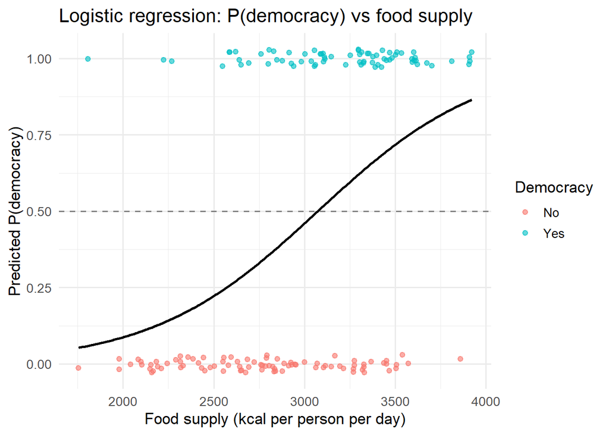

```r
grid <- tibble(food_supply_kcal_per_person_day =
                 seq(min(d_food$food_supply_kcal_per_person_day),
                     max(d_food$food_supply_kcal_per_person_day), length.out = 200))
grid$p <- predict(logit_food, grid, type = "response")

ggplot() +
  geom_jitter(data = d_food,
              aes(food_supply_kcal_per_person_day, as.numeric(Democracy == "Yes"),
                  color = Democracy), height = 0.03, alpha = 0.6) +
  geom_line(data = grid, aes(food_supply_kcal_per_person_day, p), linewidth = 1) +
  geom_hline(yintercept = 0.5, linetype = "dashed", color = "grey50") +
  labs(title = "Logistic regression: P(democracy) vs food supply",
       x = "Food supply (kcal per person per day)", y = "Predicted P(democracy)") +
  theme_minimal(base_size = 13)
```

#### Model evaluation-p-values, accuracy, cv for overfitting, roc, auc

```r
p_in  <- predict(logit_food, type = "response")
acc_lf_train <- mean((p_in > 0.5) == (d_food$Democracy == "Yes"))
table(Predicted = ifelse(p_in > 0.5, "Yes", "No"), Actual = d_food$Democracy)
```

```
         Actual
Predicted No Yes
      No  63  25
      Yes 24  48
```

```r
cv_lf <- cv_logit(d_food, Democracy ~ food_supply_kcal_per_person_day)
roc_lf_train <- roc(d_food$Democracy, p_in, levels = c("No", "Yes"), direction = "<", quiet = TRUE)

tibble(model = "logistic, food supply",
       training_accuracy = acc_lf_train,
       cv_accuracy = cv_lf$accuracy,
       gap = acc_lf_train - cv_lf$accuracy,
       train_auc = as.numeric(auc(roc_lf_train)),
       cv_auc = as.numeric(auc(cv_lf$roc)))
```

```
# A tibble: 1 × 6
  model                 training_accuracy cv_accuracy     gap train_auc cv_auc
  <chr>                             <dbl>       <dbl>   <dbl>     <dbl>  <dbl>
1 logistic, food supply             0.694       0.688 0.00625     0.759  0.757
```

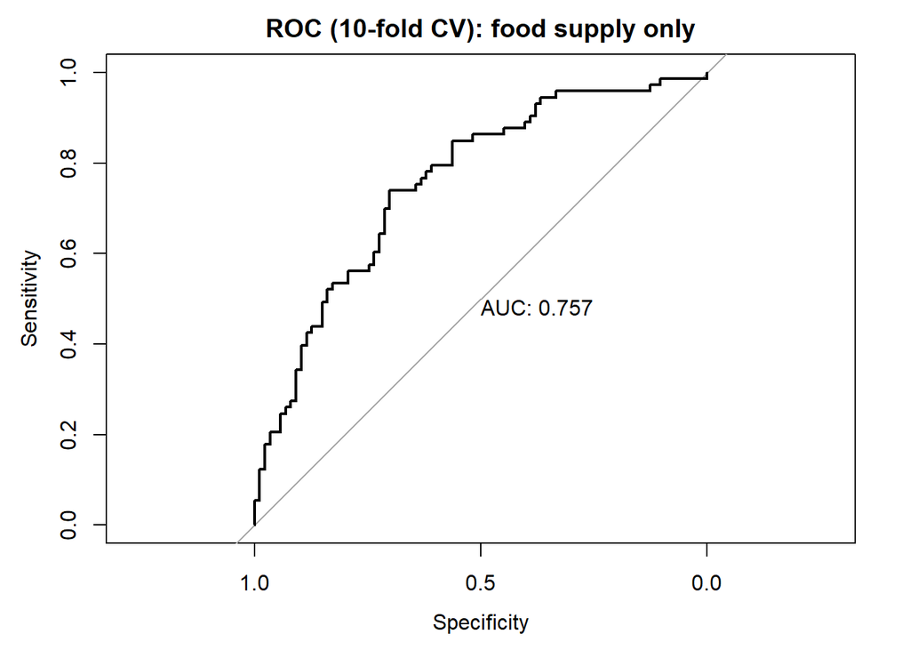

```r
plot(cv_lf$roc, main = "ROC (10-fold CV): food supply only", print.auc = TRUE)
```

Food supply is a highly significant predictor (p < 0.001). Each additional 100 kcal per person per day multiplies the odds of being a democracy by about 1.24, and the predicted probability crosses 0.5 at about 3,070 kcal per person per day. Training accuracy (0.69) and CV accuracy (0.69) are nearly identical, so there is no overfitting, and the CV AUC of about 0.76 means the model ranks a random democracy above a random non-democracy about three quarters of the time: useful, but far from perfect.

### All variable model

#### Model

```r
logit_all <- glm(Democracy ~ sanitation_access_pct + food_supply_kcal_per_person_day +
                   murder_deaths_per_100k + child_deaths_per_100k,
                 data = d_all, family = binomial)
summary(logit_all)
```

```
Call:
glm(formula = Democracy ~ sanitation_access_pct + food_supply_kcal_per_person_day +
    murder_deaths_per_100k + child_deaths_per_100k, family = binomial,
    data = d_all)

Coefficients:
                                  Estimate Std. Error z value Pr(>|z|)
(Intercept)                     -0.7312862  2.6700456  -0.274   0.7842
sanitation_access_pct           -0.0220822  0.0195846  -1.128   0.2595
food_supply_kcal_per_person_day  0.0011044  0.0006455   1.711   0.0871 .
murder_deaths_per_100k           0.0323732  0.0202584   1.598   0.1100
child_deaths_per_100k           -0.0246673  0.0096699  -2.551   0.0107 *
---
Signif. codes:  0 '***' 0.001 '**' 0.01 '*' 0.05 '.' 0.1 ' ' 1

(Dispersion parameter for binomial family taken to be 1)

    Null deviance: 210.06  on 151  degrees of freedom
Residual deviance: 159.87  on 147  degrees of freedom
AIC: 169.87

Number of Fisher Scoring iterations: 6
```

#### Equation of model

```r
round(coef(logit_all), 5)
```

```
                    (Intercept)           sanitation_access_pct
                       -0.73129                        -0.02208
food_supply_kcal_per_person_day          murder_deaths_per_100k
                        0.00110                         0.03237
          child_deaths_per_100k
                       -0.02467
```

$$\log\left(\frac{\hat p}{1-\hat p}\right) = -0.7313 + (-0.0221)\,\text{Sanitation} + 0.0011\,\text{Food} + 0.0324\,\text{Murder} + (-0.0247)\,\text{ChildDeaths}$$

#### Model evaluation-p-values, accuracy, cv for overfitting, roc, auc

```r
p_in <- predict(logit_all, type = "response")
acc_la_train <- mean((p_in > 0.5) == (d_all$Democracy == "Yes"))
table(Predicted = ifelse(p_in > 0.5, "Yes", "No"), Actual = d_all$Democracy)
```

```
         Actual
Predicted No Yes
      No  51  10
      Yes 30  61
```

```r
cv_la <- cv_logit(d_all, Democracy ~ sanitation_access_pct + food_supply_kcal_per_person_day +
                    murder_deaths_per_100k + child_deaths_per_100k)
roc_la_train <- roc(d_all$Democracy, p_in, levels = c("No", "Yes"), direction = "<", quiet = TRUE)

tibble(model = "logistic, all variables",
       training_accuracy = acc_la_train,
       cv_accuracy = cv_la$accuracy,
       gap = acc_la_train - cv_la$accuracy,
       train_auc = as.numeric(auc(roc_la_train)),
       cv_auc = as.numeric(auc(cv_la$roc)))
```

```
# A tibble: 1 × 6
  model                   training_accuracy cv_accuracy    gap train_auc cv_auc
  <chr>                               <dbl>       <dbl>  <dbl>     <dbl>  <dbl>
1 logistic, all variables             0.737       0.704 0.0329     0.811  0.776
```

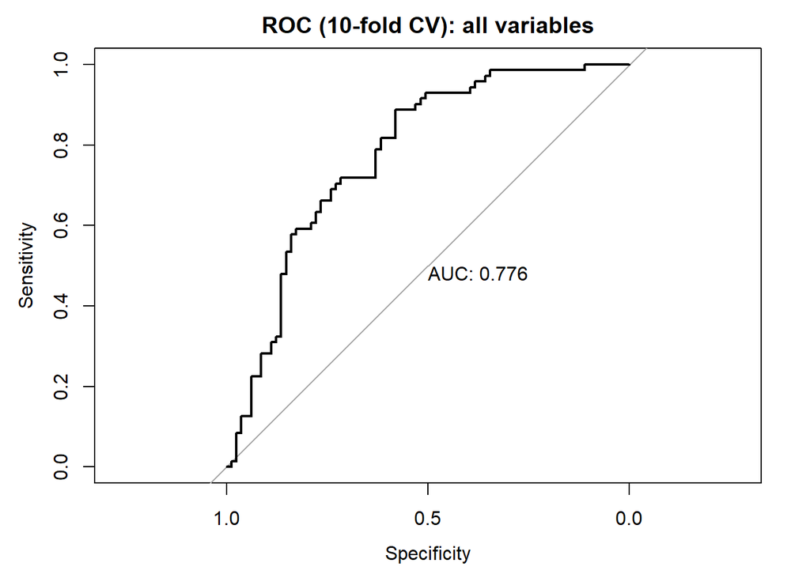

```r
plot(cv_la$roc, main = "ROC (10-fold CV): all variables", print.auc = TRUE)
```

In the all-variable model only child deaths per 100k is significant at the 5% level (p = 0.011; +10 child deaths per 100k multiplies the odds of democracy by about 0.78). Food supply (p = 0.087), the murder rate (p = 0.110) and sanitation access (p = 0.26) are not significant once the others are included. Sanitation, food supply and child deaths are strongly related to one another (all reflect development), so the model cannot separate their effects well, and the positive sign on murder rate is not a causal finding, just something the model uses to adjust for the other variables. Training accuracy is 0.74 vs CV accuracy 0.70 (gap of about 3 points), and the CV AUC is about 0.78 (training AUC 0.81), so there is a small amount of overfitting.

### Which model was best?

The all-variable model is slightly better on paper (CV accuracy 0.70 vs 0.69, CV AUC 0.78 vs 0.76), but the improvement is small, it has a larger training-vs-CV gap, and only one of its four predictors is individually significant. The single variable model is almost as good, has no overfitting gap, and has a one-sentence interpretation. We consider the extra complexity of the multivariate model **not clearly worth it**, although it is the better choice if the only goal is to maximize AUC.

## Best model

```r
# For a fair side-by-side, the single-variable models use their own complete cases
# and the all-variable models use theirs (a few more rows are dropped).
tibble(
  model = c("kNN, food supply", "kNN, all variables",
            "Logistic, food supply", "Logistic, all variables"),
  n = c(nrow(d_food), nrow(d_all), nrow(d_food), nrow(d_all)),
  cv_accuracy = c(acc_knn_food_cv, acc_knn_all_cv, cv_lf$accuracy, cv_la$accuracy),
  cv_auc = c(NA, NA, as.numeric(auc(cv_lf$roc)), as.numeric(auc(cv_la$roc)))
)
```

```
# A tibble: 4 × 4
  model                       n cv_accuracy cv_auc
  <chr>                   <int>       <dbl>  <dbl>
1 kNN, food supply          160       0.706 NA
2 kNN, all variables        152       0.698 NA
3 Logistic, food supply     160       0.688  0.757
4 Logistic, all variables   152       0.704  0.776
```

All four models land in the same narrow range (CV accuracy 0.69 to 0.71), well above the 53 to 55% baseline but far from perfect, and the differences are within the noise for a sample of about 150 countries. We would recommend the **single variable logistic regression using food supply**. It gives up almost nothing in accuracy (0.69 vs 0.70 to 0.71), shows no overfitting, needs the fewest complete observations, and is fully interpretable (odds ×1.24 per 100 kcal, cutoff near 3,070 kcal), and it also gives probabilities and an AUC (0.76) that kNN does not. Yes, there is a tradeoff: kNN has no equation and can capture non-linear patterns but is hard to explain, and the all-variable logistic model has the highest AUC (0.78) but its coefficients are hard to interpret because the predictors are correlated. Because democracy status is poorly predicted by these development indicators in every model, none of them should be used as more than a rough screening tool.

## Your question

**Question:** Is the link between sanitation access and child mortality the same in democracies and non-democracies? In other words, at the same level of sanitation access, do democracies still have lower child death rates, or is the gap just a reflection of democracies being wealthier and having better infrastructure?

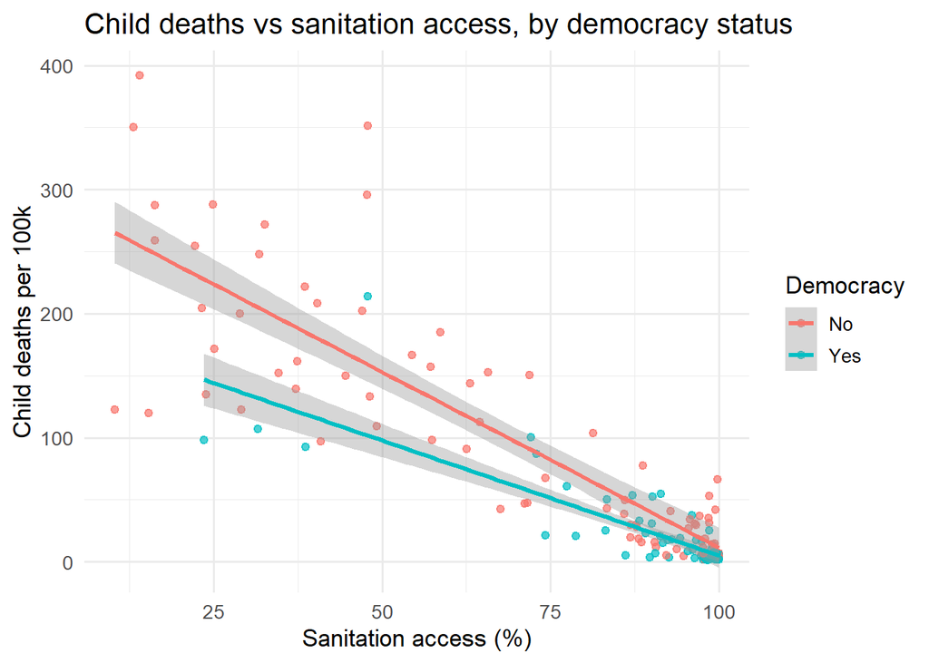

```r
project2_merged |>
  drop_na(sanitation_access_pct) |>
  ggplot(aes(sanitation_access_pct, child_deaths_per_100k, color = Democracy)) +
  geom_point(alpha = 0.7) +
  geom_smooth(method = "lm", se = TRUE) +
  labs(title = "Child deaths vs sanitation access, by democracy status",
       x = "Sanitation access (%)", y = "Child deaths per 100k",
       color = "Democracy") +
  theme_minimal(base_size = 13)
```

```r
q_dat <- project2_merged |> drop_na(sanitation_access_pct)
summary(lm(child_deaths_per_100k ~ sanitation_access_pct * Democracy, data = q_dat))$coefficients
```

```
                                      Estimate Std. Error    t value
(Intercept)                         294.683443 11.1257160  26.486695
sanitation_access_pct                -2.834202  0.1484882 -19.087060
DemocracyYes                       -104.008307 30.3809898  -3.423467
sanitation_access_pct:DemocracyYes    0.977112  0.3391025   2.881465
                                       Pr(>|t|)
(Intercept)                        1.976570e-58
sanitation_access_pct              5.642599e-42
DemocracyYes                       7.973160e-04
sanitation_access_pct:DemocracyYes 4.539272e-03
```

```r
q_dat |> group_by(Democracy) |>
  summarise(n = n(), r = cor(sanitation_access_pct, child_deaths_per_100k),
            mean_sanitation = mean(sanitation_access_pct),
            mean_child = mean(child_deaths_per_100k))
```

```
# A tibble: 2 × 5
  Democracy     n      r mean_sanitation mean_child
  <fct>     <int>  <dbl>           <dbl>      <dbl>
1 No           82 -0.856            68.9       99.5
2 Yes          72 -0.826            91.5       20.8
```

**Answer:** No, the relationship is not the same, but the gap largely disappears where sanitation is good. In both groups child deaths fall steeply as sanitation access rises (correlation about -0.86 in non-democracies and -0.83 in democracies). However, the interaction term is significant (p = 0.005): the slope is about -2.8 child deaths per 100k per percentage point of sanitation in non-democracies but only about -1.9 in democracies. The model implies that at 50% sanitation access democracies have roughly 55 fewer child deaths per 100k than non-democracies, at 80% about 26 fewer, and at 100% only about 6 fewer. So part of the overall gap in child deaths (about 100 vs 21 per 100k) is simply because democracies have much higher sanitation access (mean 91% vs 69%), and the remaining democracy advantage is concentrated among countries with poor sanitation. This is an association from 154 countries and not evidence that democracy causes lower child mortality; wealth, which we do not have in this data, is a likely common driver.